# Data Manipulation and Visualiation Workshop Midwest Updated February 2023

# Supplementary Material

### AFS Style Guidelines

These style guidelines are based on Glassic et al.’s 2019 paper titled “Creating Figures in R that Meet the AFS Style Guide: Standardization and Supporting Script” in Fisheries. We discussed most of the information in this script, and we will not discuss the following script as it is just here for you reference if you would like to attempt standardizing figures for AFS style guidelines. The code does not explain when to use its suggestions or why.

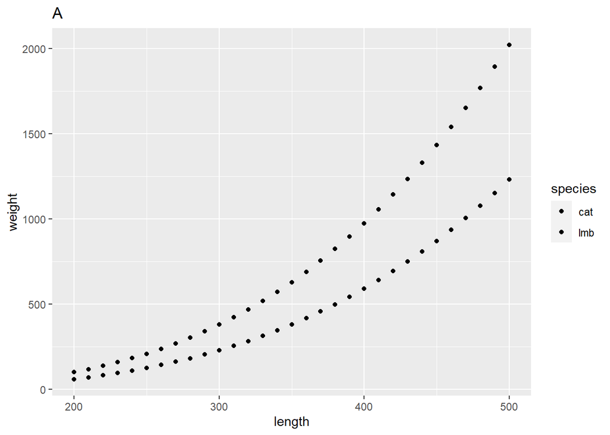

```r
#load ggplot2 and other useful packages
library(tidyverse)

#load package for combining figures
library(gridExtra)
#generate length and weight data for Channel Catfish and Largemouth Bass, and put in dataframe
length <- seq(from = 200, to = 500, by = 10)

species <- c(rep("lmb", 31), rep("cat", 31))

a_lmb <- (-5.528)
b_lmb <- (3.273)
a_cat <- (-5.800)
b_cat <- (3.294)
weight_lmb <- 10^(a_lmb + b_lmb * log10(length))
weight_cat <- 10^(a_cat + b_cat * log10(length))
weight <- c(weight_lmb, weight_cat)
length_weight_data <- data.frame(species, length, weight)
#make default ggplot figure with a legend and annotated label
len_wt_default <- ggplot(data = length_weight_data, aes(x = length, y = weight, fill = species)) +
geom_point() +
labs(title = "A")
#view the plot, will appear in R plotting window
len_wt_default
```

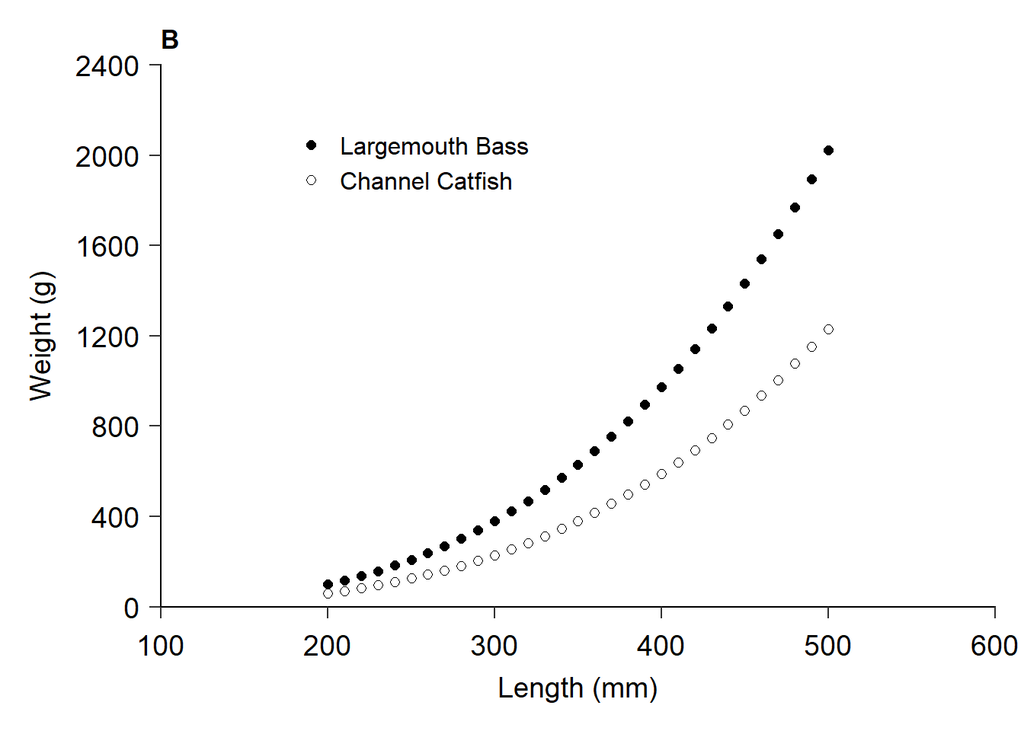

```r
#make ggplot figure that meets AFS style guidelines
len_wt_afs <- ggplot(data = length_weight_data, aes(x = length, y = weight, fill = species)) +
#set symbol shape and size
geom_point(shape = 21, size = 2) +
#set the limits and tick breaks for the y-axis
scale_y_continuous (limits = c(0,2400), expand = c(0,0), breaks = seq(0,2400,400)) +
#set the limits and tick spacing for the x-axis
scale_x_continuous(limits = c(100,600), expand = c(0,0), breaks = seq(100,600,100)) +
#adjust the order of the legend, make new labels, and select the symbol colors
scale_fill_manual(limits = c("lmb", "cat"), labels = c("Largemouth Bass", "Channel Catfish"), values = c("black", "white")) +
#add B to figure
ggtitle ("B") +
#label the y-axis
ylab("Weight (g)") +
#label the x-axis
xlab("Length (mm)") +
#add legend title, but left blank here because we want a legend but no title
labs(fill = "") +
#makes the figure background white without grid lines
theme_classic() +
#below are theme settings that provide unlimited control of your figure and can be a template for other figures
#set the size, spacing, and color for the y-axis and x-axis titles
theme (axis.title.y = element_text(size = 14, margin = margin(t = 0, r = 10, b = 0, l = 0), colour = "black"),
       axis.title.x = element_text(size = 14, margin = margin(t = 10, r = 0, b = 0, l = 0), colour = "black"),
       #set the font type
       text = element_text(family = "Times New Roman"),
       #modify plot title, the B in this case
       plot.title = element_text(face = "bold", family = "Arial"),
       #position the legend on the figure
       legend.position = c(0.3,0.85),
       #adjust size of text for legend
       legend.text = element_text(size = 12),
       #margin for the plot
       plot.margin = unit(c(0.5, 0.5, 0.5, 0.5), "cm"),
       #set size of the tick marks for y-axis
       axis.ticks.y = element_line(size = 0.5),
       #set size of the tick marks for x-axis
       axis.ticks.x = element_line(size = 0.5),
       #adjust length of the tick marks
       axis.ticks.length = unit(0.2,"cm"),
       #set size and location of the tick labels for the y axis
       axis.text.y = element_text(colour = "black", size = 14, angle = 0, vjust = 0.5, hjust = 1,
                                  margin = margin(t = 0, r = 5, b = 0, l = 0)),
       #set size and location of the tick labels for the x axis
       axis.text.x = element_text(colour = "black", size = 14, angle = 0, vjust = 0, hjust = 0.5,
                                  margin = margin(t = 5, r = 0, b = 0, l = 0)),
       #set the axis size, color, and end shape
       axis.line = element_line(colour = "black", size = 0.5, lineend = "square"))
#view the plot, will appear in R plotting window
len_wt_afs
```

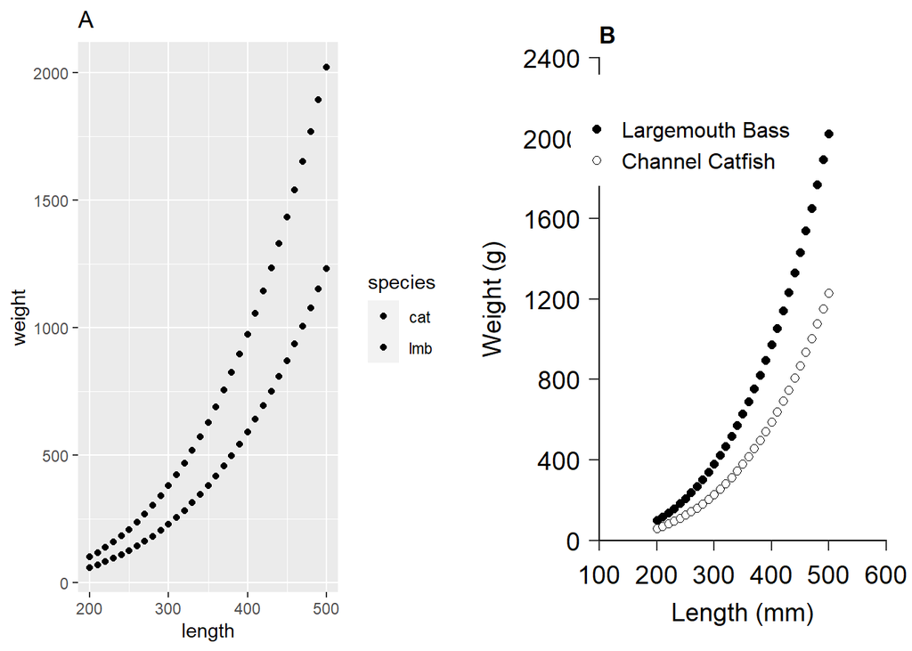

```r
#arrange the two plots side by side using the gridExtra package
ggplot_figure <- grid.arrange(len_wt_default, len_wt_afs, ncol = 2)
```

```r
#save the plot as a .tiff as a very large file, which is publication quality
ggsave(ggplot_figure, file = "ggplot_figure.tiff", width = 20.32, height = 7.62, units = "cm", dpi = 300)
```